# Introduction

I wanted a way to try and pick a single cell pipeline. My best guess was to try and find the one that worked most like the STAR/rsem pipeline we use for the bulk RNA-seq. If we sum all of the single cells together, does it act like having run the bulk single cell pipeline on the concatination of all the single cell reads?

Throughout this notebook "sc" stands for a sum of all the single cell libraries and "pop" refers to pooling the single cell fastqs into a population and feeding the combined fastq through the a bulk RNA-seq pipeline.

Given a single cell "genes" by "cell" matrix like the following, I calculate the sum along the gene axis.

$\sum_{i=0}^{c} \begin{pmatrix} x_{00} & x_{01} & \ldots & x_{0c} \\ x_{10} & x_{11} & \ldots & x_{1c} \\ \vdots & \vdots & \ddots & \vdots \\ x_{g0} & x_{g1} & \ldots & x_{gc} \\ \end{pmatrix} = \begin{pmatrix} x_{00} + x_{01} + \ldots + x_{oc} \\ x_{10} + x_{11} + \ldots + x_{1c} \\ \vdots \\ x_{g0} + x_{g1} + \ldots + x_{gc} \\ \end{pmatrix} = \begin{pmatrix} x_{o} \\ x_{1} \\ \vdots \\ x_{g} \\ \end{pmatrix}$

I then compare that single column sum to the equivalent population column extracted from the bulk run.

Kallisto and Salmon's bulk pipelines generate transcript level quantifications, to compute the equivalent gene quantifications, I added a the gene id each transcript belonged to, then summed entries with the same gene ID together.

Everything was aligned with indices built with from the ENCODE mm10 M21 male files, kallisto and salmon decoy used the rsem.transcripts.fa file from ENCFF363TFV for their transcriptome model and salmon no decoy used rsem.idx.fa and should be re-run. the salmon decoy index might need to be rebuilt as well as it was provided the spikes twice.

| Cellranger | 3.1.0 |
| --- | --- |
| STAR | 2.7.5a |
| Kallisto | 0.46.2 |
| Salmon | 1.2.1 |

# Setup

See build-10x-e10.5-population-looms.html to see how the quantification matrixes were built. See compare-10x-sum-vs-population.html to see the full notebook.

# Sum of Gene Counts by Algorithm

This was originally a check to make sure I'd loaded the files correctly, but it's also interesting to see how aggressively different algorithms call genes.

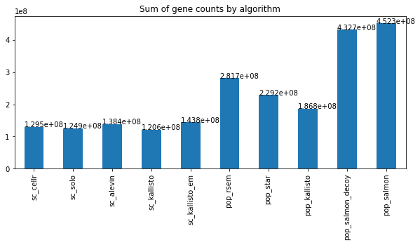

```python
plot_sum_of_genes_by_algorithm()
```

# Genes detected by counts (All gene types)

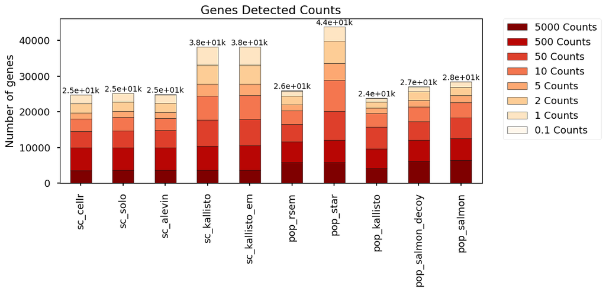

```python
_ = plot_gene_detection_histogram(bin_library_quantification(gene_counts, "Counts"), "Genes Detected Counts", show_genes_detected=True, figsize=(10,4))
```

# Sum of Gene TPMs by Algorithm

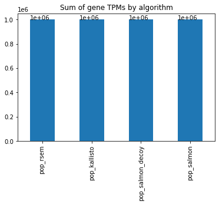

```python
ax = gene_tpms.sum(axis=0).plot(kind='bar')
ax.set_title('Sum of gene TPMs by algorithm')
for p in ax.patches:
    ax.annotate('{:.3}'.format(p.get_height()), (p.get_x(), p.get_height()))
```

# Genes detected by TPM (All gene types)

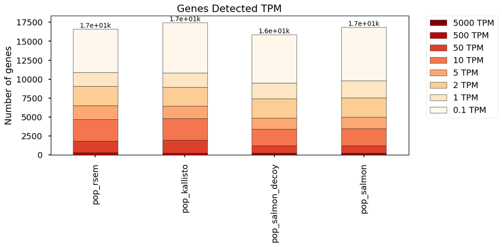

```python
_ = plot_gene_detection_histogram(bin_library_quantification(gene_tpms, "TPM"), "Genes Detected TPM", show_genes_detected=True, figsize=(10,4))
```

# Sum of transcript counts by Algorithm

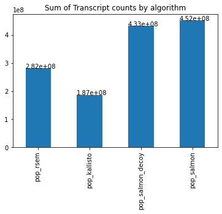

```python
ax = transcript_counts.sum(axis=0).plot(kind='bar')
_ = ax.set_title('Sum of Transcript counts by algorithm')
for p in ax.patches:
    ax.annotate('{:.2e}'.format(int(p.get_height())), (p.get_x(), p.get_height()))
```

# Transcripts dected counts (All gene types)

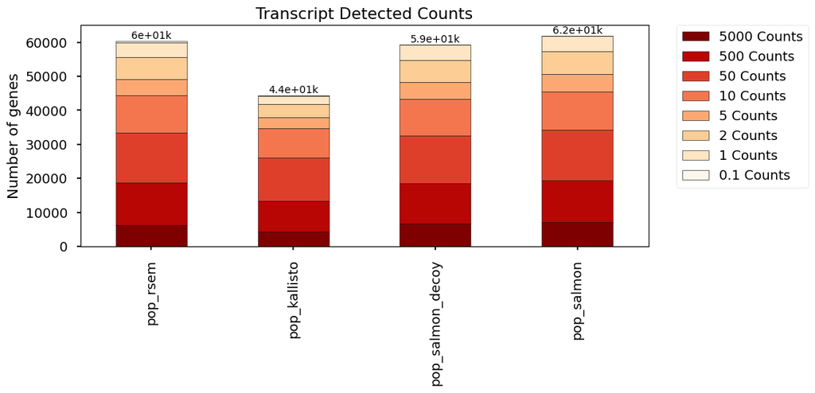

```python
_ = plot_gene_detection_histogram(bin_library_quantification(transcript_counts, "Counts"), "Transcript Detected Counts", show_genes_detected=True, figsize=(10,4))
```

# Sum of transcript TPMs by Algorithm

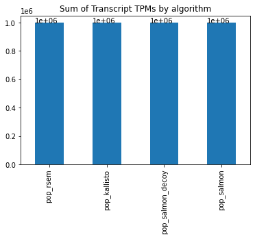

```python
ax = transcript_tpms.sum(axis=0).plot(kind='bar')
_ = ax.set_title('Sum of Transcript TPMs by algorithm')
for i, p in enumerate(ax.patches):
    ax.annotate('{:.3}'.format(p.get_height()), (p.get_x(), p.get_height()))
```

# Transcripts dected using TPMs (All gene types)

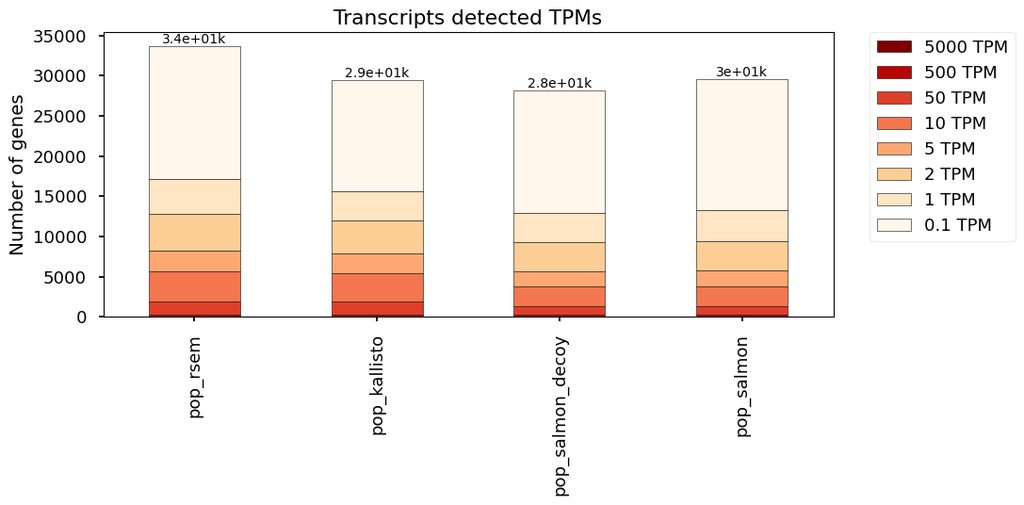

```python
_ = plot_gene_detection_histogram(bin_library_quantification(transcript_tpms, "TPM"), "Transcripts detected TPMs", show_genes_detected=True, figsize=(10,4))
```

# Show algorithms with similar performance

I want to show a scatter plot of all the algorithms, but there are enough of them it's hard to read, so I want to show some algorithms that can be removed because they perform similarly to each other

# Compare 10x Cellranger, STAR Solo, and Population STAR and RSEM

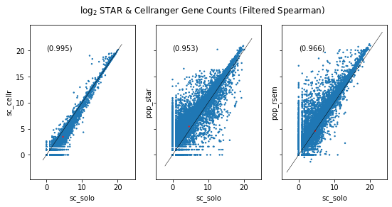

```python
plot_star()
```

Single Cell STAR Solo matches Single Cell Cellranger quite well.

# Single Cell Kallisto gene counts

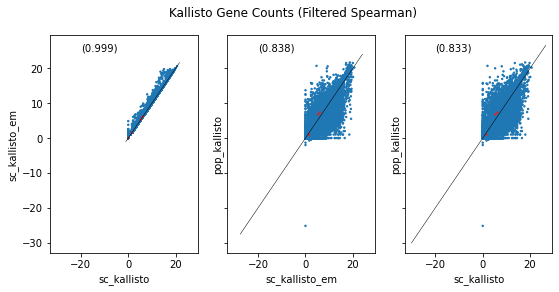

```python
plot_kallisto_gene_counts()
```

The extra EM run with Kallisto doesn't seem to change much.

# Compare Salmon and Alevin Gene Counts

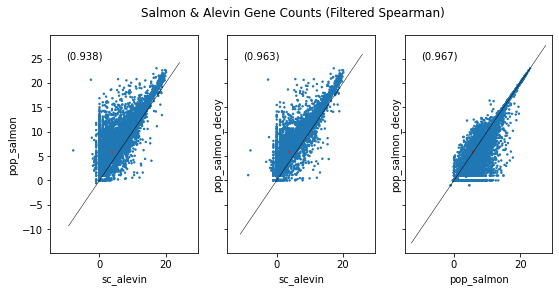

```python
plot_salmon_gene_counts()
```

I didn't have a lot of space, so I'm still going to filter pop_salmon_decoy as it's still pretty similar to pop_salmon

# Compare Gene Counts

Remove the following categories from the big scatter plot because they have a mate they're fairly similar to.

```python
#columns = ['sc_rsem', 'pop_rsem', 'pop_star', 'pop_kallisto', 'pop_salmon_decoy', 'pop_salmon'];
columns = ['sc_solo', 'sc_alevin', 'sc_kallisto', 'pop_rsem', 'pop_star', 'pop_kallisto', 'pop_salmon']
print('Removed: ', set(gene_counts_log2.columns).difference(columns))
```

```
Removed:  {'sc_cellr', 'pop_salmon_decoy', 'sc_kallisto_em'}
```

# Compare Gene Counts

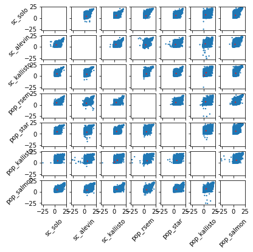

```python
f = scatter_matrix(gene_counts_log2, gene_color, columns=columns, rotation=45)
```

# Heat map of gene count correlations

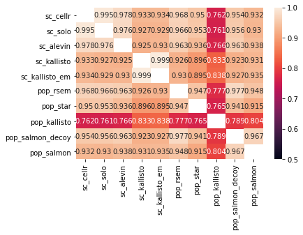

```python
_ = seaborn.heatmap(gene_count_scores['rafa_spearman'], annot=True, fmt='.3g', vmin=vmin, vmax=1.0)
```

The population runs were treated as single ended, so maybe the estimates I used for the fragment sizes were wrong?

# Scatter matrix comparing Cellranger to population rsem and STAR gene counts

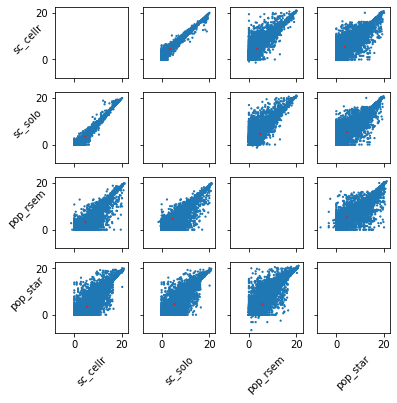

```python
columns = ['sc_cellr', 'sc_solo', 'pop_rsem', 'pop_star']
f = scatter_matrix(gene_counts_log2,gene_color, columns=columns, rotation=45)
```

# Compare cellranger to alevin and population salmon gene counts

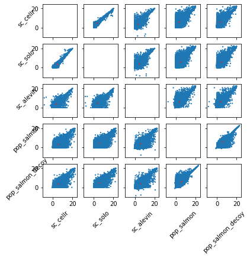

```python
columns = ['sc_cellr', 'sc_solo', 'sc_alevin', 'pop_salmon', 'pop_salmon_decoy']
f = scatter_matrix(gene_counts_log2, gene_color, columns=columns, rotation=45)
```

# Compare Gene TPMs

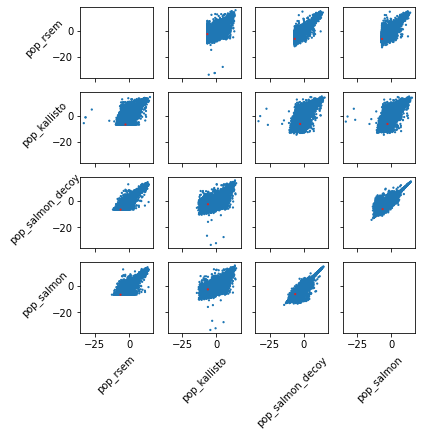

```python
f = scatter_matrix(gene_tpms_log2, gene_color, rotation=45)
```

# Compare Gene TPM correlations

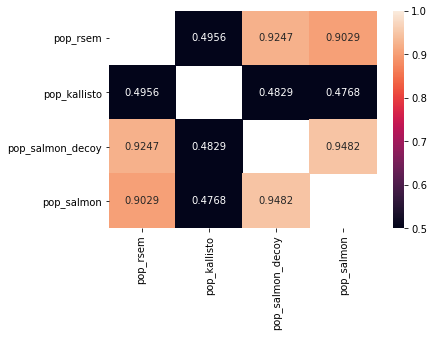

```python
_ = seaborn.heatmap(gene_tpm_scores['rafa_spearman'], annot=True, fmt='.4g', vmin=vmin, vmax=1.0)
```

# Compare Transcript Counts

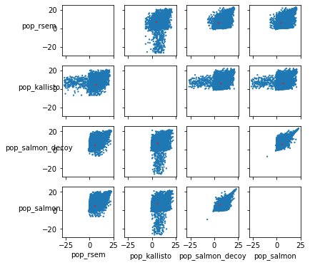

```python
#columns = ['sc_rsem', 'pop_rsem', 'pop_kallisto', 'pop_salmon_decoy', 'pop_salmon']
f = scatter_matrix(transcript_counts_log2, transcript_color)
```

# Compare transcript count correlations

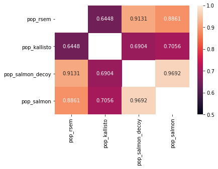

```python
_ = seaborn.heatmap(transcript_count_scores['rafa_spearman'], annot=True, fmt='.4g', vmin=vmin, vmax=1.0)
```

# Compare Transcript TPMs

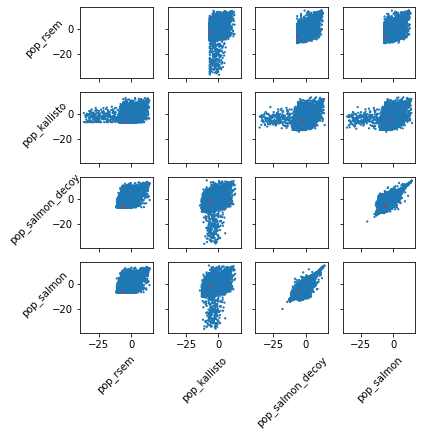

```python
#columns=['sc_rsem', 'pop_rsem', 'pop_kallisto', 'pop_salmon_decoy', 'pop_salmon']
f = scatter_matrix(transcript_tpms_log2, transcript_color, rotation=45)
```

# Compare transcript TPM correlations

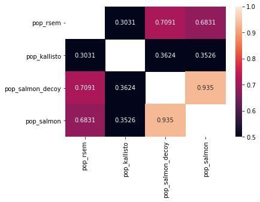

```python
_ = seaborn.heatmap(transcript_tpm_scores['rafa_spearman'], annot=True, fmt='.4g', vmin=vmin, vmax=1.0)
```

# Highlight Kallisto

Zoom in on kallisto versus other algorithms.

In the following plots the one furthest to the right is RSEM vs Salmon (without decoy)

# Compare Kallisto Single Cell Counts

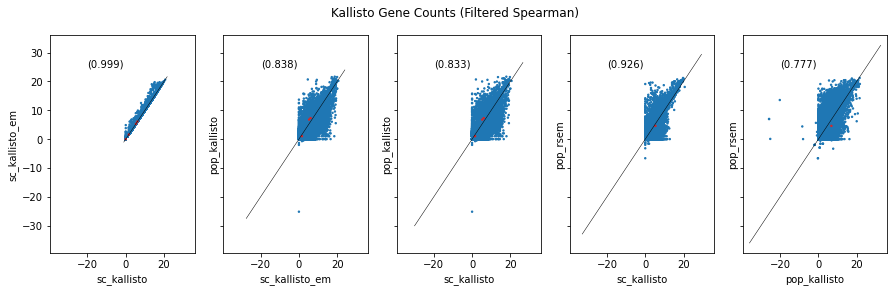

```python
plot_kallisto_sc_gene_counts()
```

## Plot Kallisto Gene Counts

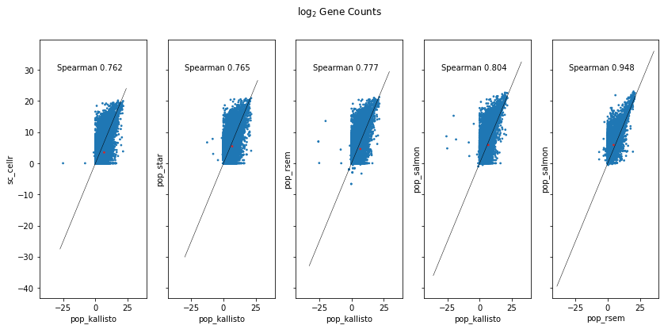

```python
plot_kallisto_pop_gene_counts()
```

# What if we just floor kallisto gene counts?

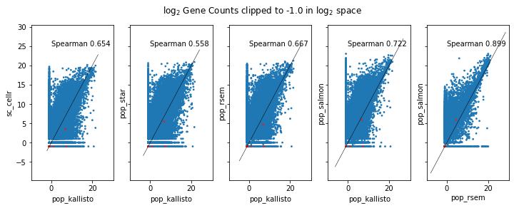

```python
plot_kallisto_gene_counts_floored()
```

Well that didn't help.

## Kallisto Population Gene TPMs

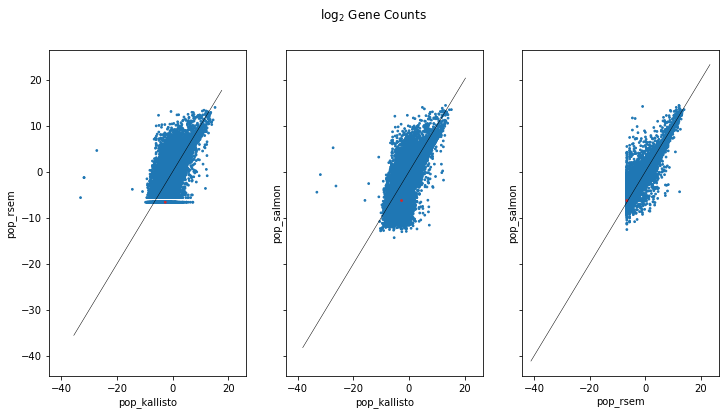

```python
plot_kallisto_gene_tpm()
```

## Kallisto Population Transcript Counts

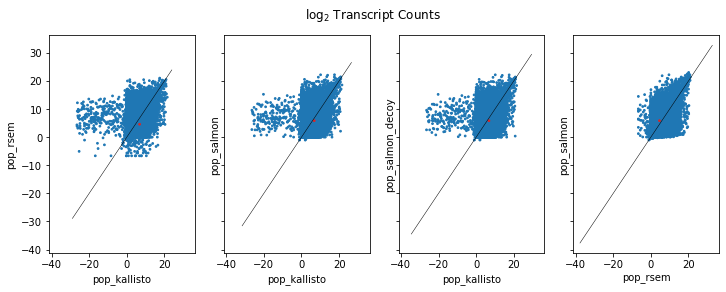

```python
plot_kallisto_transcript_counts()
```

## Kallisto Population Transcript TPMs

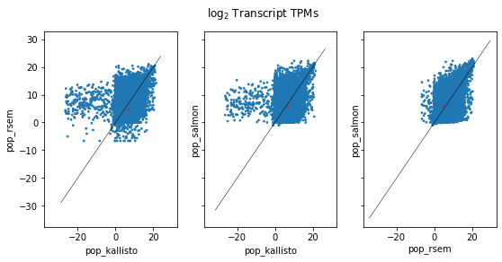

```python
plot_kallisto_transcript_tpms()
```

# Conclusions

# Plot Graveyard

# Kallisto vs Rsem Gene TPMs

```python
gene_tpms.columns
```

```
Index(['pop_rsem', 'pop_kallisto', 'pop_salmon_decoy', 'pop_salmon'], dtype='object')
```

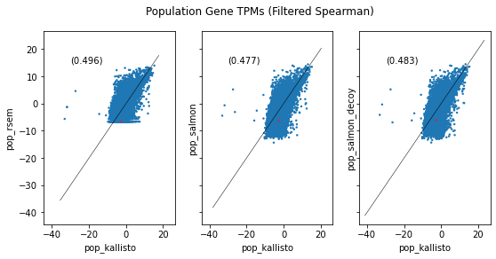

```python
plot_kallisto_gene_tpms()
```

# Compare SmartSeq Salmon gene counts and TPMs with and without decoy

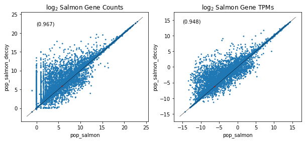

```python
plot_salmon_genes()
```

# Compare SmartSeq Salmon transcript counts and TPMs with and without decoy

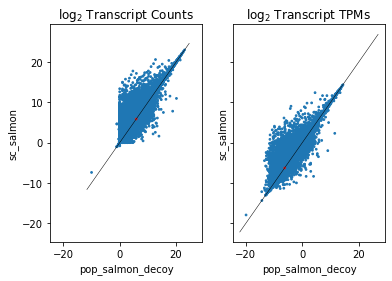

```python
plot_salmon_transcripts()
```